# lmtp_demo

Klaus Frieler

2026-08-08

## Motivating Example from Ch. 20

First we sue TLME on the motivating example 20.1 from Ch. 20, without and with an additional L1 effect, added by us.

### Original data

```r
sim20_1_d1 <- sim20_l1 %>%
  mutate(L0 = 0) %>%
  lmtp_tmle(trt = c("A0", "A1"),
            outcome = "Y",
            time_vary = list("L0", "L1"),
            outcome_type = "continuous",
            shift = static_binary_on)
sim20_1_d0 <- sim20_l1 %>%
  mutate(L0 = 0) %>%
  lmtp_tmle(trt = c("A0", "A1"),
            outcome = "Y",
            time_vary = list("L0", "L1"),
            outcome_type = "continuous",
            shift = static_binary_off)
lmtp_contrast(sim20_1_d1, ref = sim20_1_d0, type = "additive")
```

```
## LMTP Contrast: additive
```

```
## Null hypothesis: theta == 0
```

```
##
##   shift  ref estimate std.error conf.low conf.high p.value
## 1  59.8 59.4    0.441      2.42    -4.31      5.19   0.856
```

### Original data plus added L1 effect

```r
sim20_1_l1_d1 <- sim20_l1 %>%
  mutate(L0 = 0) %>%
  lmtp_tmle(trt = c("A0", "A1"),
            outcome = "Y2",
            time_vary = list("L0", "L1"),
            outcome_type = "continuous",
            folds = 1,
            shift = static_binary_on)

sim20_1_l1_d0 <- sim20_l1 %>%
  mutate(L0 = 0) %>%
  lmtp_tmle(trt = c("A0", "A1"),
            outcome = "Y2",
            time_vary = list("L0", "L1"),
            outcome_type = "continuous",
            folds = 1,
            shift = static_binary_off)

lmtp_contrast(sim20_1_l1_d1, ref = sim20_1_l1_d0, type = "additive")
```

```
## LMTP Contrast: additive
```

```
## Null hypothesis: theta == 0
```

```
##
##   shift  ref estimate std.error conf.low conf.high p.value
## 1  44.8 51.8    -6.95       2.7    -12.2     -1.66  0.0101
```

### Traditional models

Now compare this to the ATE estimated with `marginaleffects::avg_predictions` base on simple linear regression

```r
fit <- sim20_l1 %>%
  glm(Y2 ~ A0 + A1 + L1, data = .)

fit_always_treat <- fit %>%
  marginaleffects::avg_predictions(newdata = sim20_l1 %>%
                                     mutate(A0 = 1 ,
                                            A1 = 1)) %>%
  as_tibble()

fit_never_treat <- fit %>%
  marginaleffects::avg_predictions(newdata = sim20_l1 %>%
                                     mutate(A0 = 0 ,
                                            A1 = 0)) %>%
  as_tibble()
ATE <- fit_always_treat$estimate - fit_never_treat$estimate
se_ATE <- sqrt(fit_always_treat$std.error^2  + fit_never_treat$std.error^2)
ci_lo_ATE <- ATE - 1.96 * se_ATE
ci_hi_ATE <- ATE + 1.96 * se_ATE
tibble(estimate = ATE,
       std.error = se_ATE,
       conf.low  = ci_lo_ATE,
       conf.high = ci_hi_ATE)
```

```
## # A tibble: 1 × 4
##   estimate std.error conf.low conf.high
##      <dbl>     <dbl>    <dbl>     <dbl>
## 1    -16.9      1.48    -19.9     -14.0
```

Finally, simple t-tests for both cases

```r
naive <- sim20_l1 %>%
  filter(A0 == 0 & A1 == 0 | A0 == 1 & A1 == 1) %>%
  mutate(trt = A0)

naive_ttest <-
  bind_cols(naive %>% rstatix::t_test(Y ~ trt),
          naive %>% rstatix::cohens_d(Y ~ trt) %>%
            select(effsize, magnitude)) %>%
  mutate(type = "no_effect")

naive_l1 <- sim20_l1 %>%
  filter(A0 == 0 & A1 == 0 | A0 == 1 & A1 == 1) %>%
  mutate(trt = A0)

naive_l1_ttest <-
  bind_cols(naive_l1 %>% rstatix::t_test(Y2 ~ trt),
          naive_l1 %>% rstatix::cohens_d(Y2 ~ trt) %>%
            select(effsize, magnitude))%>%
  mutate(type = "l1_effect")

ATE_no_effect <- naive %>%
  group_by(trt) %>%
  summarise(Y = mean(Y)) %>% pull(Y) %>% diff()

ATE_l1_effect <- naive %>%
  group_by(trt) %>%
  summarise(Y2 = mean(Y2)) %>% pull(Y2) %>% diff()

bind_rows(naive_ttest %>% mutate(estimate = ATE_no_effect),
          naive_l1_ttest %>% mutate(estimate = ATE_l1_effect)) %>%
  select(-starts_with("group")) %>%
  select(type, outcome = .y., estimate, cohens_d = effsize, p, everything())
```

```
## # A tibble: 2 × 10
##   type   outcome estimate cohens_d       p    n1    n2 statistic    df magnitude
##   <chr>  <chr>      <dbl>    <dbl>   <dbl> <int> <int>     <dbl> <dbl> <ord>
## 1 no_ef… Y          -12.2    0.676 1.67e-4    48    96      3.90  105. moderate
## 2 l1_ef… Y2         -23.8    1.07  1.5 e-8    48    96      6.15  103. large
```

We see that the simple models give (erroneous) significant effects for always treat vs. never treat

## Smoking Cessation and Weight Gain

Recall the data from Ch. 13 to 15 about Smoking cessation and weight gain. The G-Estimation, for example, gave an ATE of 3.44 (without censoring). Can we reproduce this value using TMLE?

```r
nhefs_complete_ext <- nhefs_complete %>%
  mutate(age_p2 = age * age,
         smokeintensity_p2 = smokeintensity^2,
         smokeyrs_p2 = smokeyrs^2,
         wt71_p2 = wt71^2
         )
covariates <- c("sex",
                "race",
                "age",
                "age_p2",
                "education",
                "smokeintensity",
                "smokeintensity_p2",
                "smokeyrs",
                "smokeyrs_p2",
                "exercise",
                "active",
                "wt71",
                "wt71_p2")
nhefs_d1 <- nhefs_complete_ext %>%
  lmtp_tmle(trt = "qsmk",
            outcome = "wt82_71",
            baseline = covariates,
            outcome_type = "continuous",
            shift =  static_binary_on)

nhefs_d0 <- nhefs_complete_ext %>%
  lmtp_tmle(trt = "qsmk",
            outcome = "wt82_71",
            baseline = covariates,
            outcome_type = "continuous",
            shift =  static_binary_off)
lmtp_contrast(nhefs_d1, ref = nhefs_d0)
```

```
## LMTP Contrast: additive
```

```
## Null hypothesis: theta == 0
```

```
##
##   shift  ref estimate std.error conf.low conf.high p.value
## 1  5.24 1.77     3.46       0.5     2.48      4.45  <0.001
```

## Kang & Schafer’s Devilish Example

Now we have a look at simulated data taken from the paper by Kang & Schafer (2007). The outcome is based on 4 normally distributed covariates `z1, Z2, Z3, z4` and four deliberately modified version `x1, x2, x3, x4`, using complex non-linear function while keeping basic correlation roughly intact. the treatment is actually a collider based on the four covariates, so there should be no treatment effect. We see `TMLE` completedly fail using the “wrong” predictors. Naive regression fails as well.

Let’s have a look at the data.

```r
head(kang_schafer)
```

```
## # A tibble: 6 × 16
##       y    x1    x2    x3    x4       z1     z2     z3     z4  p_id    pi     t
##   <dbl> <dbl> <dbl> <dbl> <dbl>    <dbl>  <dbl>  <dbl>  <dbl> <int> <dbl> <dbl>
## 1  170. 0.951  9.86 0.220  328. -0.101   -0.263 -0.834 -1.63      1 0.552     1
## 2  216. 1.22   9.64 0.237  337.  0.398   -0.885  1.17  -0.764     2 0.344     0
## 3  189. 1.20   9.02 0.225  298.  0.362   -2.38   0.572 -0.375     3 0.514     1
## 4  176. 1.73   9.38 0.161  279.  1.10    -2.47  -1.27  -0.838     4 0.115     0
## 5  188. 0.321  9.63 0.136  483. -2.27    -0.412  0.944  2.38      5 0.760     1
## 6  228. 1.00  10.5  0.216  491.  0.00153  0.922 -0.863  1.23      6 0.579     1
## # ℹ 4 more variables: prop_correct <dbl>, prop_wrong <dbl>,
## #   y_pred_correct <dbl>, y_pred_wrong <dbl>
```

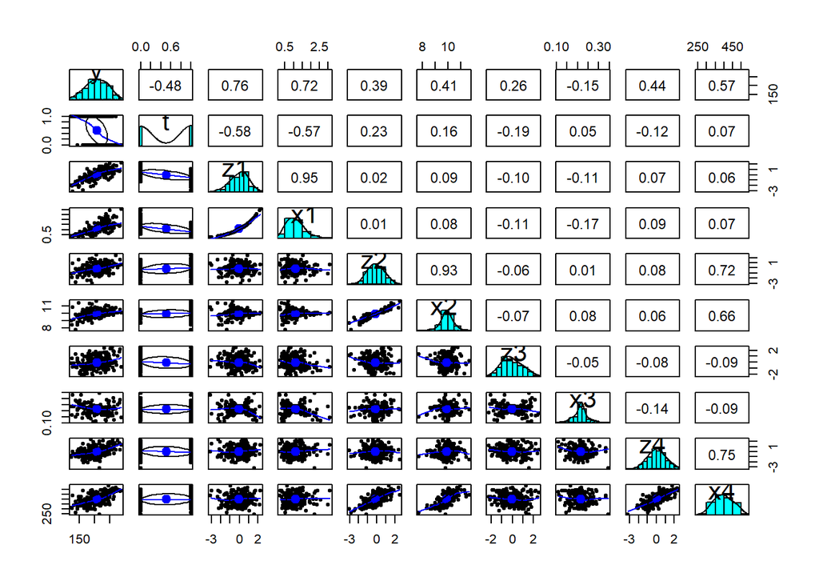

```r
#psych::pairs.panels(kang_schafer %>%
#                      select(starts_with(c("x", "z"))))
psych::pairs.panels(kang_schafer %>%
                      select(y, t, z1, x1, z2, x2, z3, x3, z4, x4))
```

First, naive modeling.

```r
fit_wrong <- kang_schafer %>% lm(y ~ x1 + x2 + x3 + x4 + t, data = .)
summary(fit_wrong)
```

```
##
## Call:
## lm(formula = y ~ x1 + x2 + x3 + x4 + t, data = .)
##
## Residuals:
##     Min      1Q  Median      3Q     Max
## -53.273 -10.897   0.592  11.350  41.126
##
## Coefficients:
##              Estimate Std. Error t value Pr(>|t|)
## (Intercept)   4.91003   21.66616   0.227    0.821
## x1           38.27342    2.61627  14.629  < 2e-16 ***
## x2            4.49989    2.78858   1.614    0.108
## x3           -7.48287   29.74600  -0.252    0.802
## x4            0.31250    0.02563  12.191  < 2e-16 ***
## t           -14.67233    2.69286  -5.449 1.53e-07 ***
## ---
## Signif. codes:  0 '***' 0.001 '**' 0.01 '*' 0.05 '.' 0.1 ' ' 1
##
## Residual standard error: 15.14 on 194 degrees of freedom
## Multiple R-squared:  0.8209, Adjusted R-squared:  0.8163
## F-statistic: 177.8 on 5 and 194 DF,  p-value: < 2.2e-16
```

```r
fit_always_treat_ks <-
  fit_wrong %>%
    marginaleffects::avg_predictions(
      newdata = kang_schafer %>% mutate(t = 1))
fit_never_treat_ks <-
  fit_wrong %>%
    marginaleffects::avg_predictions(
      newdata = kang_schafer %>% mutate(t = 0))
ATE <- fit_always_treat_ks$estimate - fit_never_treat_ks$estimate
se_ATE <- sqrt(fit_always_treat_ks$std.error^2  + fit_never_treat_ks$std.error^2)
ci_lo_ATE <- ATE - 1.96 * se_ATE
ci_hi_ATE <- ATE + 1.96 * se_ATE
tibble(estimate = ATE,
       std.error = se_ATE,
       conf.low  = ci_lo_ATE,
       conf.high = ci_hi_ATE)
```

```
## # A tibble: 1 × 4
##   estimate std.error conf.low conf.high
##      <dbl>     <dbl>    <dbl>     <dbl>
## 1    -14.7      2.43    -19.4     -9.90
```

Let’s see the TMLE models.

```r
ks_z_d1 <- kang_schafer %>% lmtp_tmle(
  outcome = "y",
  trt = "t",
  baseline = sprintf("z%d", 1:4),
  outcome_type = "continuous",
  shift = static_binary_on
)

ks_z_d0 <- kang_schafer %>% lmtp_tmle(
  outcome = "y",
  trt = "t",
  baseline = sprintf("z%d", 1:4),
  outcome_type = "continuous",
  shift = static_binary_off
)

ks_x_d1 <- kang_schafer %>% lmtp_tmle(
  outcome = "y",
  trt = "t",
  baseline = sprintf("x%d", 1:4),
  outcome_type = "continuous",
  shift = static_binary_on
)

ks_x_d0 <- kang_schafer %>% lmtp_tmle(
  outcome = "y",
  trt = "t",
  baseline = sprintf("x%d", 1:4),
  outcome_type = "continuous",
  shift = static_binary_off
)

bind_rows(
  lmtp_contrast(ks_x_d1, ref = ks_x_d0) %>%
    pluck("estimates") %>%
    as_tibble() %>%
    mutate(type = "Wrongly specified"),
  lmtp_contrast(ks_z_d1, ref = ks_z_d0) %>%
    pluck("estimates") %>%
    as_tibble() %>%
    mutate(type = "Correctly specified"))%>%
  select(type, everything())
```

```
## # A tibble: 2 × 8
##   type                shift   ref estimate std.error conf.low conf.high  p.value
##   <chr>               <dbl> <dbl>    <dbl>     <dbl>    <dbl>     <dbl>    <dbl>
## 1 Wrongly specified    203.  216.  -12.6       2.24   -17.0      -8.19   1.86e-8
## 2 Correctly specified  207.  207.   -0.168     0.208   -0.575     0.240  4.20e-1
```

We see a complete failure for the misspecified models.

### References

Díaz, I., Williams, N., Hoffman, K. L., & Schenck, E. J. (2023a). Nonparametric Causal Effects Based on Longitudinal Modified Treatment Policies. Journal of the American Statistical Association, 118(542), 846–857. https://doi.org/10.1080/01621459.2021.1955691

Díaz, I., Williams, N., Hoffman, K. L., & Schenck, E. J. (2023b). Nonparametric Causal Effects Based on Longitudinal Modified Treatment Policies. Journal of the American Statistical Association, 118(542), 846–857. https://doi.org/10.1080/01621459.2021.1955691

Hernán, M., & Robins, J. M. (2023). Causal inference: What if (First edition). Taylor and Francis.

Hines, O., Dukes, O., Diaz-Ordaz, K., & Vansteelandt, S. (2022). Demystifying Statistical Learning Based on Efficient Influence Functions. The American Statistician, 76(3), 292–304. https://doi.org/10.1080/00031305.2021.2021984

Hoffman, K. L., Schenck, E. J., Satlin, M. J., Whalen, W., Pan, D., Williams, N., & Díaz, I. (2022). Comparison of a Target Trial Emulation Framework to Cox Regression to Estimate the Effect of Corticosteroids on COVID-19 Mortality. Intensive Care and Critical Care Medicine. https://doi.org/10.1101/2022.05.27.22275037

Kang, J. D. Y., & Schafer, J. L. (2007). Demystifying Double Robustness: A Comparison of Alternative Strategies for Estimating a Population Mean from Incomplete Data. Statistical Science, 22(4). https://doi.org/10.1214/07-STS227

Muñoz, I. D., & Van Der Laan, M. (2012). Population Intervention Causal Effects Based on Stochastic Interventions. Biometrics, 68(2), 541–549. https://doi.org/10.1111/j.1541-0420.2011.01685.x

Petersen, M. L., & Van Der Laan, M. J. (2014). Causal Models and Learning from Data: Integrating Causal Modeling and Statistical Estimation. Epidemiology, 25(3), 418–426. https://doi.org/10.1097/EDE.0000000000000078

Rubin, D. B. (2005). Causal Inference Using Potential Outcomes: Design, Modeling, Decisions. Journal of the American Statistical Association, 100(469), 322–331. https://doi.org/10.1198/016214504000001880

Williams et al. (2025), Beyond the Average Treatment Effect, [Workshop/Tutorial https://beyondtheate.com/](https://beyondtheate.com/)